# ANOVA

# Analysis of Variance (ANOVA)

ANOVA, also Analysis of Variance: a common approach to **testing a hypothesis with 2 or more groups**. One-way ANOVA, can be considered an extension of the t-test whenever more than 2 groups are being tested.

The factor, or categorical variable, is often referred to as the ‘treatment’ in the ANOVA setting.

ANOVA involves partiitioning the data’s total variation into variation between and within groups. This procedure is known as Analysis of Variance as sources of variation are examined serparately.

The data is still assumed to be normally distributed with mean and standard deviation. Stating the hypothesis is also similar to previous examples when there were only two samples of interest.

Consider an experiment designed to test yields from a control and two different treatments. The returns of each group are collected, and the dry weights of the plants are measured. Is there a difference in the means of the treatments?

There is no reason to assume there is a difference between the control and the two treatments.

```r
library(car)
```

```
Ignoring unknown aesthetics: data
```

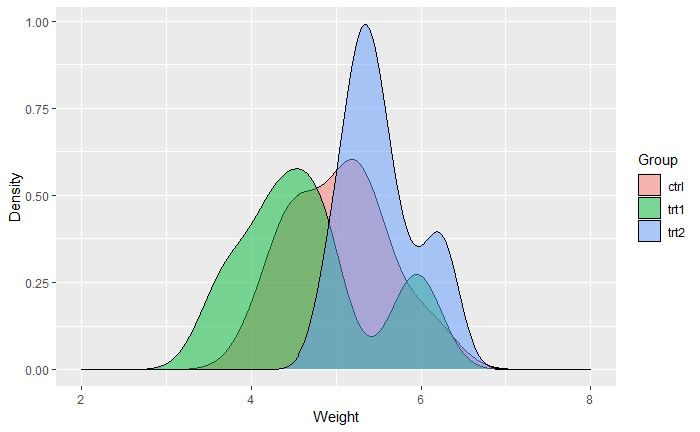

```r
ggplot(PlantGrowth, aes(weight)) +
  geom_density(aes(data=weight, fill=group), position='identity', alpha=0.5) +
                 labs(x="Weight", y="Density")+ scale_fill_discrete(name='Group') +
                 scale_x_continuous(limits=c(2,8))
```

```
[1] 14 16
```

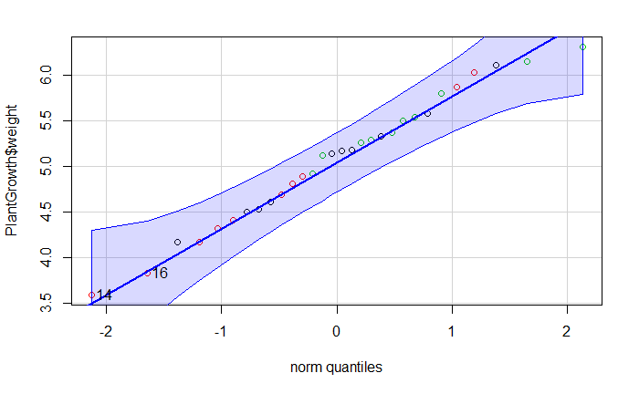

```r
qqPlot(PlantGrowth$weight, col=PlantGrowth$group)
```

**The Q-Q plot provides further evidence of normality as most of the points fall on the line.**

## ANOVA in R

Analysis of Vaiance is used on models, typically the linear regression model.